# Assessing the biometric Attendance of the faculty members**

### Introduction:

In this report, the analysis focuses on examining a large dataset collected by a biometric attendance system. The dataset comprises Userid, Check-IN, and Check-OUT details (date and time), and department. The study's objective is to assess the attendance patterns and the dedication of faculty members to their duties. The aim is to demonstrate any potential relationships among these columns.

To commence, potential relationships among the variables Checktime, Checktime2, Check type, and user id have been explored. The primary interest lies in identifying the most regular or punctual employee. Given that the data is in time series format, it was necessary to convert Checktime and Checktime2 to the datetime format. Additionally, the analysis includes an assessment of the number of days a faculty member checked in and whether their check-in times were on schedule.

This research is founded on several assumptions, including the assumption that regular faculty members are also punctual.

The report addresses the following questions:

1: What is the overall attendance pattern of the faculty members?

2: Who is the most regular user?

3: Who is the most punctual user?

4: Can we determine the number of days a faculty member did not sign in?

5: Is it feasible to categorize the days when faculty members did not sign in?

## Importing Modules

```python
import pandas as pd
import numpy as np
import matplotlib.pyplot as plt
import datetime as dt
from pylab import rcParams

%matplotlib inline
plt.rcParams["figure.figsize"] = [30, 8]
rcParams['font.size'] = 20
rcParams['axes.facecolor'] = 'white'
```

## Importing dataset:

Below is a dataset extracted from 'BiometricAttendance.csv' and saved to a dataframe object.

```python
# Importing BiometricAttendance.csv file
biometric_Attendance_Df = pd.read_csv("BiometricAttendance.csv")
```

First, determine how much data there is to work with.

```python
biometric_Attendance_Df.shape
```

```
(8830, 5)
```

The dataset comprises 8830 records across 5 columns: DeptName, Userid, Checktime, Checktime2, and Checktype.

We will conduct an initial assessment of the dataset to explore the data.

```python
biometric_Attendance_Df.head(20)
```

|  | DeptName | Userid | Checktime | Checktime2 | Checktype |
| --- | --- | --- | --- | --- | --- |
| 0 | Soc. Sci. | 566 | 1-Jul-21 | 11:41 AM | Check IN |
| 1 | Soc. Sci. | 566 | 1-Jul-21 | 6:29 PM | Check OUT |
| 2 | Soc. Sci. | 566 | 2-Jul-21 | 11:17 AM | Check IN |
| 3 | Soc. Sci. | 566 | 2-Jul-21 | 6:11 PM | Check OUT |
| 4 | Soc. Sci. | 566 | 6-Jul-21 | 11:02 AM | Check IN |
| 5 | Soc. Sci. | 566 | 7-Jul-21 | 11:17 AM | Check IN |
| 6 | Soc. Sci. | 566 | 7-Jul-21 | 6:39 PM | Check OUT |
| 7 | Soc. Sci. | 566 | 8-Jul-21 | 11:16 AM | Check IN |
| 8 | Soc. Sci. | 566 | 8-Jul-21 | 5:39 PM | Check OUT |
| 9 | Soc. Sci. | 566 | 9-Jul-21 | 10:41 AM | Check IN |
| 10 | Soc. Sci. | 566 | 9-Jul-21 | 5:52 PM | Check OUT |
| 11 | Soc. Sci. | 566 | 12-Jul-21 | 10:52 AM | Check IN |
| 12 | Soc. Sci. | 566 | 12-Jul-21 | 5:28 PM | Check OUT |
| 13 | Soc. Sci. | 566 | 13-Jul-21 | 11:09 AM | Check IN |
| 14 | Soc. Sci. | 566 | 13-Jul-21 | 5:55 PM | Check OUT |
| 15 | Soc. Sci. | 566 | 14-Jul-21 | 11:05 AM | Check IN |
| 16 | Soc. Sci. | 566 | 14-Jul-21 | 5:48 PM | Check OUT |
| 17 | Soc. Sci. | 566 | 15-Jul-21 | 11:12 AM | Check IN |
| 18 | Soc. Sci. | 566 | 15-Jul-21 | 6:06 PM | Check OUT |
| 19 | Soc. Sci. | 566 | 16-Jul-21 | 9:38 AM | Check IN |

```python
biometric_Attendance_Df.tail(20)
```

|  | DeptName | Userid | Checktime | Checktime2 | Checktype |
| --- | --- | --- | --- | --- | --- |
| 8810 | Computer Sciences | 717 | 14-Dec-21 | 10:07 AM | Check IN |
| 8811 | Computer Sciences | 717 | 14-Dec-21 | 5:59 PM | Check OUT |
| 8812 | Computer Sciences | 717 | 16-Dec-21 | 10:16 AM | Check IN |
| 8813 | Computer Sciences | 717 | 17-Dec-21 | 5:22 PM | Check OUT |
| 8814 | Computer Sciences | 717 | 20-Dec-21 | 10:33 AM | Check IN |
| 8815 | Computer Sciences | 717 | 20-Dec-21 | 5:19 PM | Check OUT |
| 8816 | Computer Sciences | 717 | 21-Dec-21 | 9:28 AM | Check IN |
| 8817 | Computer Sciences | 717 | 21-Dec-21 | 5:42 PM | Check OUT |
| 8818 | Computer Sciences | 717 | 22-Dec-21 | 11:01 AM | Check IN |
| 8819 | Computer Sciences | 717 | 22-Dec-21 | 7:06 PM | Check OUT |
| 8820 | Computer Sciences | 717 | 24-Dec-21 | 9:39 AM | Check IN |
| 8821 | Computer Sciences | 717 | 24-Dec-21 | 5:24 PM | Check OUT |
| 8822 | Computer Sciences | 717 | 27-Dec-21 | 9:33 AM | Check IN |
| 8823 | Computer Sciences | 717 | 27-Dec-21 | 5:40 PM | Check OUT |
| 8824 | Computer Sciences | 717 | 28-Dec-21 | 9:44 AM | Check IN |
| 8825 | Computer Sciences | 717 | 28-Dec-21 | 5:39 PM | Check OUT |
| 8826 | Computer Sciences | 717 | 29-Dec-21 | 9:36 AM | Check IN |
| 8827 | Computer Sciences | 717 | 29-Dec-21 | 5:20 PM | Check OUT |
| 8828 | Computer Sciences | 717 | 30-Dec-21 | 10:17 AM | Check IN |
| 8829 | Computer Sciences | 717 | 31-Dec-21 | 10:35 AM | Check IN |

**Attendance pattern of overall faculty and Individual faculty memeber**

The department column has been dropped from the dataset below. Now, we can easily identify some columns that might be suitable for our use.

```python
# Removing Department column and changing date formate
df = biometric_Attendance_Df.loc[:,["Userid","Checktime","Checktime2","Checktype"]]
df.head(10)
```

|  | Userid | Checktime | Checktime2 | Checktype |
| --- | --- | --- | --- | --- |
| 0 | 566 | 1-Jul-21 | 11:41 AM | Check IN |
| 1 | 566 | 1-Jul-21 | 6:29 PM | Check OUT |
| 2 | 566 | 2-Jul-21 | 11:17 AM | Check IN |
| 3 | 566 | 2-Jul-21 | 6:11 PM | Check OUT |
| 4 | 566 | 6-Jul-21 | 11:02 AM | Check IN |
| 5 | 566 | 7-Jul-21 | 11:17 AM | Check IN |
| 6 | 566 | 7-Jul-21 | 6:39 PM | Check OUT |
| 7 | 566 | 8-Jul-21 | 11:16 AM | Check IN |
| 8 | 566 | 8-Jul-21 | 5:39 PM | Check OUT |
| 9 | 566 | 9-Jul-21 | 10:41 AM | Check IN |

get detail about the datatype of the column

```python
df.info()
```

```
<class 'pandas.core.frame.DataFrame'>
RangeIndex: 8830 entries, 0 to 8829
Data columns (total 4 columns):
 #   Column      Non-Null Count  Dtype
---  ------      --------------  -----
 0   Userid      8830 non-null   int64
 1   Checktime   8830 non-null   object
 2   Checktime2  8830 non-null   object
 3   Checktype   8830 non-null   object
dtypes: int64(1), object(3)
memory usage: 276.1+ KB
```

Converting the Checktime column type to datetime for further processing.

```python
df["Checktime"] =  pd.to_datetime(biometric_Attendance_Df['Checktime'])
```

As we can see, the checktime2 column is used to get insights about check IN and check OUT. So, it is important to convert it into time specifically.

```python
# Changing 12h Time format to 24h time format
from datetime import datetime
df["Checktime2"] = pd.to_datetime(df.loc[:,"Checktime2"])
df.head()
```

|  | Userid | Checktime | Checktime2 | Checktype |
| --- | --- | --- | --- | --- |
| 0 | 566 | 2021-07-01 | 2022-04-10 11:41:00 | Check IN |
| 1 | 566 | 2021-07-01 | 2022-04-10 18:29:00 | Check OUT |
| 2 | 566 | 2021-07-02 | 2022-04-10 11:17:00 | Check IN |
| 3 | 566 | 2021-07-02 | 2022-04-10 18:11:00 | Check OUT |
| 4 | 566 | 2021-07-06 | 2022-04-10 11:02:00 | Check IN |

```python
# Removing dates from 24h time formate column
df["Checktime2"] = pd.Series([val.time() for val in df.loc[:,"Checktime2"]])
```

before analysis, it is important check unique user's records and how many individual user in the dataset.

```python
# Finding total faculty members
uniqueid = df["Userid"].unique()
totalFmembers = len(df["Userid"].unique())
print("Total faculty member are ", totalFmembers)
```

```
Total faculty member are  72
```

When working on attendance data, it is important to determine business days.

```python
# Finding Total active days from calenders (weekdays)
total_days=len(pd.DataFrame(pd.date_range(start='2021/07/01', end='2021/12/31', freq='B')))
print("Total number of working days ",total_days)
```

```
Total number of working days  132
```

# Methodology

total active days = sum of weekdays

Total present = unique dates for check in or check out

total absent = total active days - total present

regularity= total presents/total active days *100

In punctuality = no.of days for which check_In time is less or equal to 9:25AM / total present days *100

Out punctuality = no.of days for which check_Out time is greater or equal to 5:00PM / total present days *100

check in days= No. of unique check_Ins

Not sign_In = total present days - check in days

Check out days = No. of unique check_Outs

Not sign_Out = Total present days - check_Out days

```python
present_days=np.array([])
absent_days=np.array([])
in_punctual_list=np.array([])
out_punctual_list=np.array([])
no_check_in_list=np.array([])
not_check_in_list=np.array([])
no_check_out_list=np.array([])
not_check_out_list=np.array([])
regularity_list=np.array([])

UID_df_list=list([])
for i in uniqueid:
    UID_df=df[  df['Userid'] == i]
#     UID_df_list=list.append(UID_df_list,UID_df)


    uniquedate= UID_df['Checktime'].unique()
    u_present_days = len(uniquedate)
    u_absent_days = total_days - u_present_days
    present_days=np.append(present_days, u_present_days).astype('int')
    absent_days=np.append(absent_days, u_absent_days).astype('int')
    regularity=np.round(100*(u_present_days/total_days),2)
    regularity_list=np.append(regularity_list, regularity)
    UID_df1 = UID_df[UID_df['Checktype'] == 'Check IN']
    UID_df1 = UID_df1.groupby('Checktime').first()


    in_high=UID_df1['Checktime2'] <= pd.date_range('09:25',periods=len(UID_df)).time[0]
    out_low=UID_df['Checktime2'] >= pd.date_range('17:00',periods=len(UID_df)).time[0]
    in_high=in_high.to_numpy()
    out_low=out_low.to_numpy()
    in_punctual=100*in_high.sum()/u_present_days
    out_punctual=100*out_low.sum()/u_present_days
    in_punctual_list=np.round(np.append(in_punctual_list, in_punctual),2)
    out_punctual_list=np.round(np.append(out_punctual_list, out_punctual),2)

    no_check_in = len(UID_df1)
    no_check_in_list=np.append(no_check_in_list, no_check_in).astype('int')
    not_check_in=u_present_days-no_check_in
    not_check_in_list=np.append(not_check_in_list, not_check_in).astype('int')

    no_check_out=UID_df[UID_df['Checktype'] == 'Check OUT']['Checktime'].unique().size
    no_check_out_list=np.append(no_check_out_list, no_check_out).astype('int')
    not_check_out=u_present_days-no_check_out
    not_check_out_list=np.append(not_check_out_list, not_check_out).astype('int')
```

**New Dataframe (df) with interesting pattern**

This DataFrame contains regularity, punctuality percentages for both checking in and checking out. It also shows how many days the individual faculty member checks in or checks out, as well as how many days the user didn't sign in.

```python
column_names = ["Userid","Totalpresent","Totalabsents","Regular","Punctual","Check IN days","not signin","Check OUT days","not signout"]
final_df = pd.DataFrame(columns = column_names)
final_df = pd.DataFrame({"Userid":uniqueid,"Total present":present_days,"Total absents":absent_days,"Regularity %":regularity_list,"In Punctuality %":in_punctual_list,"Out Punctuality %":out_punctual_list,"Check IN days":no_check_in_list,"not signin":not_check_in_list,"Check OUT days":no_check_out_list,"not signout":not_check_out_list})
final_df.sort_values("Userid")
final_df.head(15)
```

|  | Userid | Total present | Total absents | Regularity % | In Punctuality % | Out Punctuality % | Check IN days | not signin | Check OUT days | not signout |
| --- | --- | --- | --- | --- | --- | --- | --- | --- | --- | --- |
| 0 | 566 | 103 | 29 | 78.03 | 0.97 | 65.05 | 82 | 21 | 99 | 4 |
| 1 | 567 | 107 | 25 | 81.06 | 87.85 | 9.35 | 105 | 2 | 102 | 5 |
| 2 | 1000 | 102 | 30 | 77.27 | 4.90 | 36.27 | 88 | 14 | 83 | 19 |
| 3 | 989 | 36 | 96 | 27.27 | 5.56 | 38.89 | 16 | 20 | 32 | 4 |
| 4 | 574 | 5 | 127 | 3.79 | 0.00 | 80.00 | 1 | 4 | 5 | 0 |
| 5 | 1157 | 2 | 130 | 1.52 | 0.00 | 0.00 | 1 | 1 | 1 | 1 |
| 6 | 1158 | 36 | 96 | 27.27 | 16.67 | 22.22 | 33 | 3 | 22 | 14 |
| 7 | 1162 | 73 | 59 | 55.30 | 1.37 | 60.27 | 13 | 60 | 68 | 5 |
| 8 | 1311 | 30 | 102 | 22.73 | 0.00 | 13.33 | 12 | 18 | 25 | 5 |
| 9 | 1402 | 94 | 38 | 71.21 | 32.98 | 75.53 | 88 | 6 | 87 | 7 |
| 10 | 1403 | 42 | 90 | 31.82 | 0.00 | 35.71 | 24 | 18 | 26 | 16 |
| 11 | 1442 | 87 | 45 | 65.91 | 2.30 | 81.61 | 54 | 33 | 77 | 10 |
| 12 | 1464 | 88 | 44 | 66.67 | 98.86 | 9.09 | 88 | 0 | 15 | 73 |
| 13 | 1722 | 56 | 76 | 42.42 | 46.43 | 30.36 | 53 | 3 | 17 | 39 |
| 14 | 1900 | 1 | 131 | 0.76 | 0.00 | 0.00 | 0 | 1 | 1 | 0 |

**Attendance pattern of overall faculty**

The bar graph below displays the attendance pattern of the entire faculty. It illustrates the regularity of each employee in percentages.

The green bar represents the most regular employee.

The red bar represents an irregular faculty member.

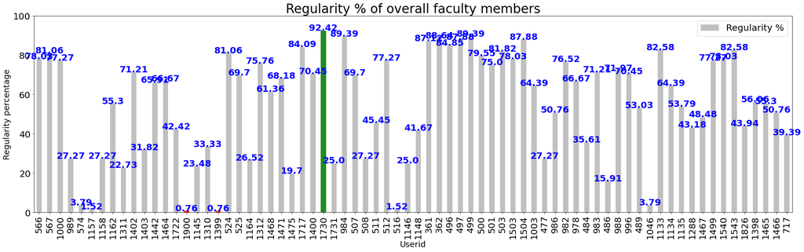

```python
x=final_df['Userid']
y=final_df['Regularity %']
colors=[]
for x in y:
    if x==y.max():
        colors.append('forestgreen')
    elif x==y.min():
        colors.append('red')
    else:
        colors.append('silver')
final_df.plot(x="Userid",y="Regularity %",kind="bar",color=colors)
for i, v in enumerate(y):
    plt.text(i, v , str(v), color='blue', fontweight='bold',ha='center' )
plt.xlabel("Userid",fontsize=18)
plt.ylabel("Regularity percentage",fontsize=18)
plt.title("Regularity % of overall faculty members",fontsize=28)
plt.ylim(0,100)
plt.show()
```

**Total present days of overall faculty members**

The plot illustrates the total number of present days of each member.

The green bar is showing the employee who is mostly present.

The red bar is showing the faculty who do not come regularly.

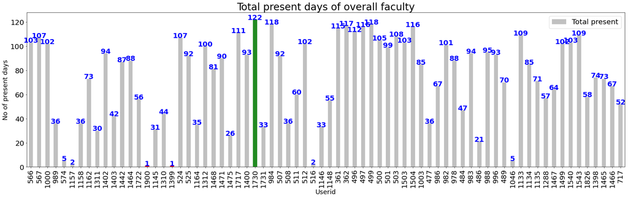

```python
x=final_df['Userid']
y=final_df['Total present']
colors=[]
for x in y:
    if x==y.max():
        colors.append('forestgreen')
    elif x==y.min():
        colors.append('red')
    else:
        colors.append('silver')
final_df.plot(x="Userid",y="Total present",kind="bar",color=colors)
for i, v in enumerate(y):
    plt.text(i, v , str(v), color='blue', fontweight='bold',ha='center')
plt.xlabel("Userid",fontsize=18)
plt.ylabel("No of present days",fontsize=18)
plt.title("Total present days of overall faculty",fontsize=28)
plt.show()
```

**Total absent days of overall faculty**

The plot illustrates the total number of absent days of each member.

The green bar shows the less absent member

The red bar is showing mostly absent employees.

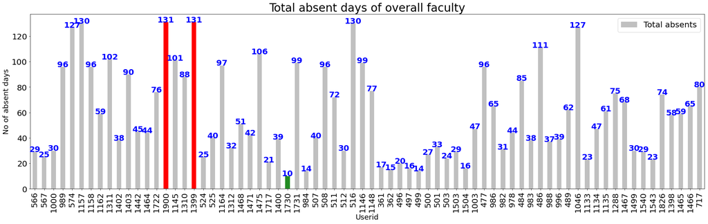

```python
x=final_df['Userid']
y=final_df['Total absents']
colors=[]
for x in y:
    if x==y.max():
        colors.append('red')
    elif x==y.min():
        colors.append('forestgreen')
    else:
        colors.append('silver')
final_df.plot(x="Userid",y="Total absents",kind="bar",color=colors)
for i, v in enumerate(y):
    plt.text(i, v , str(v), color='blue', fontweight='bold',ha='center')
plt.xlabel("Userid",fontsize=18)
plt.ylabel("No of absent days",fontsize=18)
plt.title("Total absent days of overall faculty",fontsize=28)
plt.show()
```

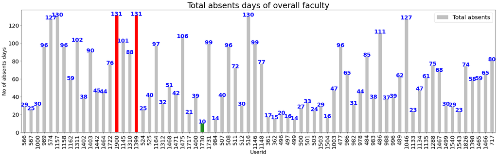

```python
x=final_df['Userid']
y=final_df['Total absents']
colors=[]
for x in y:
    if x==y.max():
        colors.append('red')
    elif x==y.min():
        colors.append('forestgreen')
    else:
        colors.append('silver')
final_df.plot(x="Userid",y="Total absents",kind="bar",color=colors)
for i, v in enumerate(y):
    plt.text(i, v , str(v), color='blue', fontweight='bold',ha='center')
plt.xlabel("Userid",fontsize=18)
plt.ylabel("No of absents days",fontsize=18)
plt.title("Total absents days of overall faculty",fontsize=28)
plt.show()
```

**Most regular employee (based on Number of days)**

The green bar shows the most regular person based on the number of days the user is present.

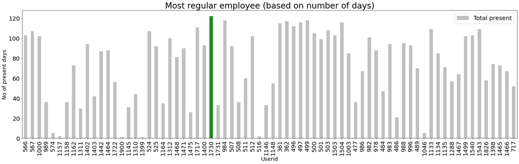

```
The most regular employee is with Userid : [1730]
```

```python
def getMostRegularEmployee():

    x=final_df['Userid']
    y=final_df['Total present']
    colors=[]
    for x in y:
        if x==y.max():
            colors.append('forestgreen')
        else:
            colors.append('silver')
    final_df.plot(x="Userid",y="Total present",kind="bar",color=colors)
    # for i, v in enumerate(y):
    #     plt.text(i, v , str(v), color='blue', fontweight='bold',ha='center')
    plt.xlabel("Userid",fontsize=18)
    plt.ylabel("No of present days",fontsize=18)
    plt.title("Most regular employee (based on number of days)",fontsize=28)
    plt.show()
    ind=final_df["Userid"][final_df['Total present']==final_df['Total present'].max()]

    return print("The most regular employee is with Userid : {employee_id}".format(employee_id=ind.tolist()))

getMostRegularEmployee()
```

**Most punctual employee (based on sign in and sign out)**

```python
def getMostPunctualEmployee():
    df3 = biometric_Attendance_Df.loc[
    ((pd.to_datetime(biometric_Attendance_Df['Checktime2']) <= pd.to_datetime('09:25:00 AM')) & (biometric_Attendance_Df['Checktype'] == 'Check IN')) |
    ((pd.to_datetime(biometric_Attendance_Df['Checktime2']) >= pd.to_datetime('04:30:00 PM')) & (biometric_Attendance_Df['Checktype'] == 'Check OUT'))
     ]   # get all the values which are in between the threshold (check in < 09:25 and checkout>04:30
    df3=biometric_Attendance_Df.groupby(['Userid']).describe() # describe returns the statistical summary grouped by Userid
    df3 = df3.Checktype  # get Checktype as df3
    index = df3.index # get all index
    condition = df3["count"] == df3['count'].max()   # check where count is max
    mostReg = index[condition] # get userid where condition is true
    return print("The most punctual employee is : {employee_id}".format(employee_id=mostReg.tolist()))
getMostPunctualEmployee()
```

```
The most punctual employee is : [1730]
```

**Use calendar to see how many days a faculty member dint sign in**

In the data science project, the resultant dataframe displays details about the total number of days per month when a user didn't sign in.

```python
import calendar
def aFacultyNotSignIn(userId):
    print(userId ," didn't sign in the follwing no. days of the month")
    # variable initialization
    Total=0
    min=7
    max=13
    Calendar={}
    df4 = df[(df["Userid"] == userId)]  # get specific user data
    userRecord = df4["Checktime"]  # save Checktime column values in userRecord
    mm=7  # file contain attendance record from july which is the 7 month of the year
    year=2021 # working on 2021s data
    output = pd.DataFrame()  # initializing dataframe
    while mm<=12:
        Calendar[calendar.month_name[mm]]=0  # add new key in Calendar dictionary
        count=0  # count is used to sum no of days didn't sign in
        for i in userRecord.unique(): # iterate over unique userRecord checktime
            if(mm == pd.to_datetime(i).month): # if month is same as in userRecord increment in count
                count +=1
                Calendar[calendar.month_name[mm]] = count # update key value in dic

        mm = mm+1  # increment mm to iterate over loop

    Calendar["Total"]=0 # add Total key in dic
    for month in range(min, max):  # for loop is used to subtract days on which user didn't sign in
        monthStart=month  # to calculate business day from start month
        monthEnd=monthStart+1 # to calculate business day from end month
        start = dt.date( year, monthStart,1)
        if(monthStart==12):
            year=year+1
            monthEnd=1
        end = dt.date( year, monthEnd,1)
        busdays = np.busday_count( start, end ) # calculate business days of each month
        actualDays=busdays - Calendar[calendar.month_name[monthStart]] # to get actual dno. of days by subtracting signed in days by business days
        Calendar[calendar.month_name[month]] = actualDays # updating dic value with actual Days
        Calendar["Total"] = Calendar["Total"] + Calendar[calendar.month_name[month]] # calculating total no of days from whole data user did not sign in
    output = output.append(Calendar, ignore_index=True) # append Calendar in output dataframe

    return  output


# calling func aFacultyNotSignIn using specific user id, any userid can be pass through func
aFacultyNotSignIn(361)
```

```
361  didn't sign in the follwing no. days of the month
```

|  | July | August | September | October | November | December | Total |
| --- | --- | --- | --- | --- | --- | --- | --- |
| 0 | 6.0 | 2.0 | 1.0 | 1.0 | 6.0 | 1.0 | 17.0 |

**The days when faculty members have not signed in**

We can identify the days when faculty members have not signed in. The code below generates the dataframe of the overall faculty members' details when they haven't signed in. The Dataframe consists of the days' names and dates when they didn't sign in.

To check the individual information, slice the data based on the user id condition in the last line.

```python
finalDf = pd.DataFrame(columns=['Userid','Day','Date']) # initialing dataframe for final output
# creating func to see days when faculty members have not signed in
def facultyMembers(userId):
    userRecordNotsignDF = pd.DataFrame(columns=['Userid','Day','Date']) # initialing dataframe for indivial user output
    df5 = df[(df["Userid"] == userId)] # get specific user data
    df5.groupby(['Checktype']) # group df5 by Checktype for further work
    userRecord = df5["Checktime"].unique() # save unique Checktime column values in userRecord
    d =pd.date_range(start='2021/07/01', end='2021/12/31', freq='B') # extracting all the business days from july 2021 to dec 2021
    userRecord=pd.to_datetime(userRecord) # converting userRecord into datetime
    userRecordNotsign= [i for i in d if i not in userRecord] # subtracting all the date the user not signed in
    for i in userRecordNotsign: # used for loop to append date and day on which the user not signed in
        x = pd.to_datetime(i)
        # userRecordNotsignDF = [userId,x.strftime("%A")]
        userRecordNotsignDF=userRecordNotsignDF.append({'Userid':userId,'Day':x.strftime("%A"),'Date':x},ignore_index=True) # appending userRecordNotsignDF
    return userRecordNotsignDF




# to check the days when faculty members have not signed in
uniqueid = df["Userid"].unique() # get uniques userids
for i in uniqueid: # loop on every user
    dfnew=facultyMembers(i)
    # print(dfnew)
    frames = [finalDf, dfnew]
    finalDf = pd.concat(frames)

userId=362
finalDf  # final dataframe with complete details of each user
finalDf[finalDf["Userid"]==userId]
```

|  | Userid | Day | Date |
| --- | --- | --- | --- |
| 0 | 362 | Monday | 2021-07-19 |
| 1 | 362 | Tuesday | 2021-07-20 |
| 2 | 362 | Wednesday | 2021-07-21 |
| 3 | 362 | Thursday | 2021-07-22 |
| 4 | 362 | Friday | 2021-07-23 |
| 5 | 362 | Wednesday | 2021-08-18 |
| 6 | 362 | Thursday | 2021-08-19 |
| 7 | 362 | Friday | 2021-08-20 |
| 8 | 362 | Monday | 2021-10-04 |
| 9 | 362 | Monday | 2021-10-18 |
| 10 | 362 | Tuesday | 2021-10-19 |
| 11 | 362 | Wednesday | 2021-11-17 |
| 12 | 362 | Thursday | 2021-11-18 |
| 13 | 362 | Monday | 2021-11-22 |
| 14 | 362 | Tuesday | 2021-11-23 |
| 15 | 362 | Wednesday | 2021-11-24 |

**Conclusion**

This report aims to address several questions providing insights into faculty members' attendance from July 2021 to December 2021. The dataset contains a total of 132 working days.

The analysis reveals that faculty members are not maintaining the institution's decorum. User IDs 1900 and 1399 each have only one day of attendance out of 132 working days over six months. In contrast, user ID 1730 consistently attended 122 out of 132 days, making them the most regular member of the faculty.

Furthermore, the analysis shows that some users consistently checked in but skipped checking out, while others checked out without checking in. This finding, although evident, provides an overview of the days when members did not sign in and the total number of days without sign-ins.

In conclusion, this report illustrates the overall attendance pattern, revealing that some individuals are not adhering to the established rules and regulations. Maintaining organizational discipline is crucial.